# PA1_tempate_Week1

Me

8/10/2020

#### Load data

```r
#Read data and omit NAs
myData <- read.csv("activity.csv")
```

Let us have a look at the first 3 rows

```r
head(myData,3)
```

```
##   steps      date interval
## 1    NA 10/1/2012        0
## 2    NA 10/1/2012        5
## 3    NA 10/1/2012       10
```

Let us look at the data type of the variables in our datasets. The **str** function can be very helful

```r
str(myData)
```

```
## 'data.frame':    17568 obs. of  3 variables:
##  $ steps   : int  NA NA NA NA NA NA NA NA NA NA ...
##  $ date    : chr  "10/1/2012" "10/1/2012" "10/1/2012" "10/1/2012" ...
##  $ interval: int  0 5 10 15 20 25 30 35 40 45 ...
```

#### Transform data

Let us change the date variable to a *date* class.

```r
myData$date <- as.Date(trimws(myData$date), "%m/%d/%Y")
```

The database looks to have many missing values. Let us have a look at them using the *summary* function

```r
summary(myData)
```

```
##      steps             date               interval
##  Min.   :  0.00   Min.   :2012-10-01   Min.   :   0.0
##  1st Qu.:  0.00   1st Qu.:2012-10-16   1st Qu.: 588.8
##  Median :  0.00   Median :2012-10-31   Median :1177.5
##  Mean   : 37.38   Mean   :2012-10-31   Mean   :1177.5
##  3rd Qu.: 12.00   3rd Qu.:2012-11-15   3rd Qu.:1766.2
##  Max.   :806.00   Max.   :2012-11-30   Max.   :2355.0
##  NA's   :2304
```

#### Omit missing values

```r
myDataFinal <- na.omit(myData)
```

What is mean total number of steps taken per day?

Calculate the total number of steps taken per day. We use the dataframe with omitted missing values

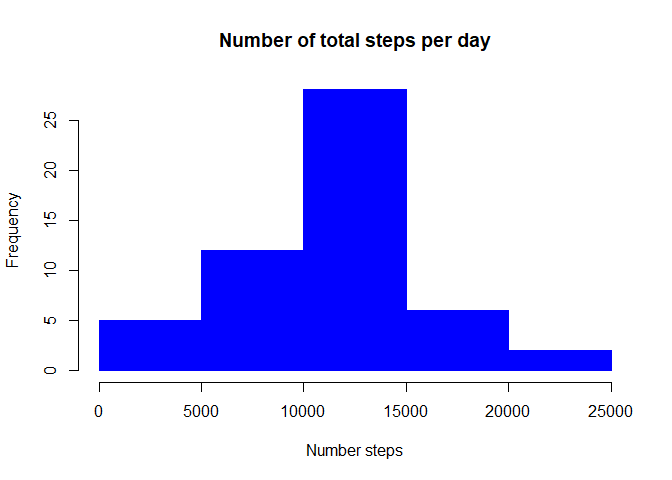

```r
## Prepare the data with totals of steps each day
histDf <- aggregate(myDataFinal["steps"], by = myDataFinal["date"], sum)

#Plot the histogram
hist(histDf$steps,
     main = "Number of total steps per day",
     xlab = "Number steps",
     col = "blue",
     border = "blue")
```

```r
steps_mean <- round (mean (histDf$steps))
steps_median <- median (histDf$steps)
```

What is the average daily activity pattern?

Make a time series plot (i.e. type = “l”) of the 5-minute interval (x-axis) and the average number of steps taken, averaged across all days (y-axis)

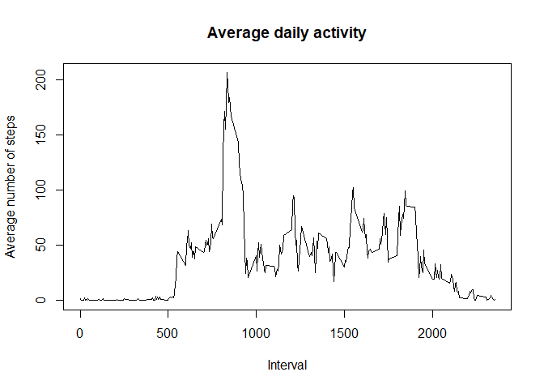

```r
# prepare a time series with average number steps in a every five minute interval.
steps_interval <- aggregate(steps ~ interval, myDataFinal, mean)

#Ploting the line graph
with (steps_interval, plot (interval, steps, type ='l',
     main="Average daily activity",
     xlab="Interval",
     ylab="Average number of steps"))
```

Which 5-minute interval, on average across all the days in the dataset, contains the maximum number of steps?

```r
max_step_interval <- which.max(steps_interval$steps)
steps_interval [max_step_interval, ]
```

```
##     interval    steps
## 104      835 206.1698
```

#### Imputing missing values

Note that there are a number of days/intervals where there are missing values (coded as NA). The presence of missing days may introduce bias into some calculations or summaries of the data.

```r
missing_values <- sapply(myData, function(x) sum(is.na(x)))
```

2. Devise a strategy for filling in all of the missing values in the dataset. The strategy does not need to be sophisticated. For example, you could use the mean/median for that day, or the mean for that 5-minute interval, etc.

```r
# We replace missing values by the daily average.  Let us first calculate the daily average number of steps.
avg_by_day <- with (myDataFinal, aggregate(steps, by = list(date = date), FUN = mean))


# merge the average datafrane with the initial dataframe
mergedData <- merge (avg_by_day, myData, by = "date")

# Capture the average where needed (i.e where steps = N/A)
mergedData$steps[is.na(mergedData$steps)] <- mergedData$x[is.na(mergedData$steps)]

# Discard average if not needed anymore
mergedData$x <- NULL
```

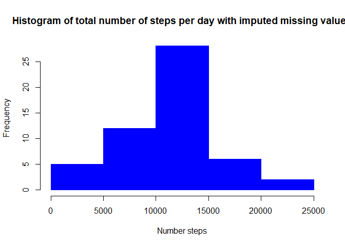

```r
histDf2 <- aggregate(mergedData["steps"], by = mergedData["date"], sum)

# create histogram of total number of steps in a day
hist(histDf2$steps,
     main ="Histogram of total number of steps per day with imputed missing values",
     xlab ="Number steps",
     col = "blue",
     border = "blue")
```

```r
mean_imputed <- round (mean(histDf2$steps))
median_imputed <- median(histDf2$steps)
```

Are there differences in activity patterns between weekdays and weekends?

1. Create a new factor variable in the dataset with two levels - “weekday” and “weekend” indicating whether a given date is a weekday or weekend day.

```r
# Create a function that split the the dataset with two levels indicating whether a given date is a weekday or weekend day.

week_day <- function(day_type) {
    day <- weekdays(as.Date(day_type, '%Y-%m-%d'))
    if  (!(day == 'Saturday' | day == 'Sunday')) {
      x <- 'Weekday'
    } else {
      x <- 'Weekend'
    }
    x
  }
```

2. Make a panel plot containing a time series plot (i.e. type = “l”) of the 5-minute interval (x-axis) and the average number of steps taken, averaged across all weekday days or weekend days (y-axis). See the README file in the GitHub repository to see an example of what this plot should look like using simulated data.

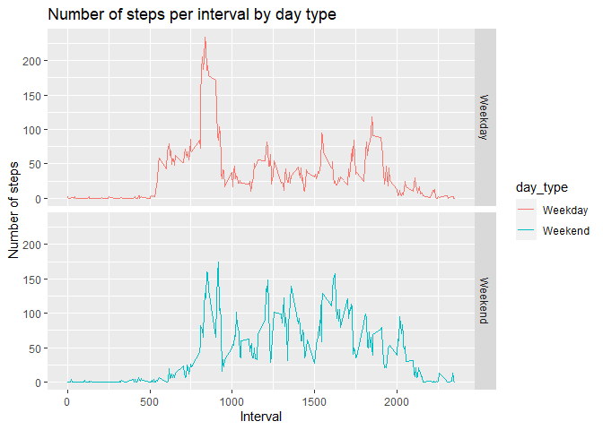

```r
# Apply the week_day function and add a new column to activity dataset
mergedData$day_type <- as.factor(sapply(mergedData$date, week_day))

# Create the aggregated data frame by intervals and day_type
steps_per_day <- aggregate(steps ~ interval + day_type, mergedData, mean)

# make the panel plot for weekdays and weekends using ggplot

#Load libraries
library(ggplot2)
library(dplyr)

steps_per_day %>% ggplot(aes(interval, steps)) +
  geom_line(stat = "identity", aes(colour = day_type)) +
  facet_grid(day_type ~.) +
  xlab ("Interval") +
  ylab ("Number of steps") +
  ggtitle("Number of steps per interval by day type")
```